# Home-to-work commuting flows within the municipalities around Paris

```r
library("spflow")
library("sf")
library("spdep")
```

# Introduction

This article illustrates the use of the **spflow** package for modeling spatial interactions using the example of home-to-work commuting flows. For our example we use information on the 71 municipalities that are located closest to the center of Paris. This data is contained in the package and was originally diffused by the French National Institutes of Statistics and Economic Studies (INSEE), and of Geographic and Forest Information (IGN). (For more information see `help(paris_data)`.)

```r
data("paris10km_municipalities")
data("paris10km_commuteflows")
```

# Data presentation

Each municipality is identified by a unique id. Additionally, we have information on the population, the median income and the number of companies.

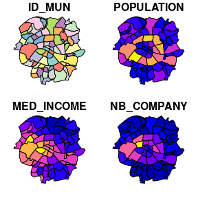

```r
drop_area <- names(paris10km_municipalities) != "AREA"
plot(paris10km_municipalities[drop_area])
```

There are three different neighborhood matrices that can be used to describe the connectivity between the municipalities.

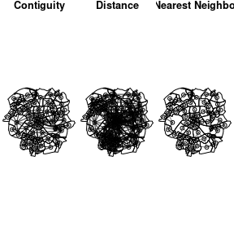

```r
old_par <- par(mfrow = c(1, 3), mar = c(0,0,1,0))

mid_points <- suppressWarnings({
    st_point_on_surface(st_geometry(paris10km_municipalities))})

paris10km_nb <- list(
  "by_contiguity" = spdep::poly2nb(paris10km_municipalities),
  "by_distance" = spdep::dnearneigh(mid_points,d1 = 0, d2 = 5),
  "by_knn" = spdep::knn2nb(knearneigh(mid_points,3))
)

plot(st_geometry(paris10km_municipalities))
plot(paris10km_nb$by_contiguity, mid_points, add = T, col = rgb(0,0,0,alpha=0.5))
title("Contiguity")

plot(st_geometry(paris10km_municipalities))
plot(paris10km_nb$by_distance,mid_points, add = T, col = rgb(0,0,0,alpha=0.5))
title("Distance")

plot(st_geometry(paris10km_municipalities))
plot(paris10km_nb$by_knn, mid_points, add = T, col = rgb(0,0,0,alpha=0.5))
title("3 Nearest Neighbors")
```

```r
par(old_par)
```

Finally, there is data on the size of the commuting flows and the distance between all pairs of municipalities.

```r
paris10km_commuteflows
```

```
#>    ID_ORIG ID_DEST   DISTANCE COMMUTE_FLOW
#> 1    75101   75101     0.0000  3771.235555
#> 2    75101   75102   787.6493   294.768992
#> 3    75101   75103  1734.3136    71.251159
#> 4    75101   75104  1811.4124    99.384682
#> 5    75101   75105  2268.2408    98.889146
#> 6    75101   75106  1513.1158    65.154062
#> 7    75101   75107  1908.6102    96.991438
#> 8    75101   75108  2083.9014   455.666096
#> 9    75101   75109  1610.6894   265.184461
#> 10   75101   75110  2339.9467    74.846270
#> 11   75101   75111  3241.7862    93.954966
#> 12   75101   75112  6939.4271   123.460322
#> 13   75101   75113  4262.6282   130.726524
#> 14   75101   75114  3771.3545    74.777413
```

[output cut: 37 more lines]

# Modeling Spatial interactions

The **spflow** package builds on the idea that flows correspond to pairwise interactions between the nodes of an origin network with the nodes of a destination network.

In our example, the origin and destination networks are the same because every municipality is both an origin and destination of a flow.

To estimate the model efficiently, the **spflow** package uses moment-based estimation methods, that exploit the relational structure of flow data. This avoids duplication arising from the fact that each municipality is at the origin and destination of many flows.

## The network objects

To describe the nodes of a network the package provides `sp_network_nodes-class` that combines attributes of the nodes with the chosen network structure. For our model we choose the contiguity based neighborhood structure.

```r
paris10km_net <-
  sp_network_nodes(
    network_id = "paris",
    node_neighborhood = nb2mat(paris10km_nb$by_contiguity),
    node_data = st_drop_geometry(paris10km_municipalities),
    node_key_column = "ID_MUN")

paris10km_net
```

```
#> Spatial network nodes with id: paris
#> --------------------------------------------------
#> Number of nodes: 71
#> Average number of links per node: 5.239
#> Density of the neighborhood matrix: 7.38% (non-zero connections)
#>
#> Data on nodes:
#>    ID_MUN POPULATION MED_INCOME NB_COMPANY AREA
#> 1   75101      17100   31842.56      14333  182
#> 2   75102      22390   30024.50      14478   99
#> 3   75103      35991   30988.00      10696  117
#> 4   75104      27769   30514.67       7412  160
#> 5   75105      60179   32950.00      10290  252
#> 6   75106      43224   38447.69      10620  215
#> 7   75107      57092   41949.00      12602  412
```

[output cut: 34 more lines]

The `sp_network_pair-class` contains all information on the pairs of nodes belonging to the origin and destination networks.

```r
paris10km_net_pairs <- sp_network_pair(
  orig_net_id = "paris",
  dest_net_id = "paris",
  pair_data = paris10km_commuteflows,
  orig_key_column = "ID_ORIG",
  dest_key_column = "ID_DEST")

paris10km_net_pairs
```

```
#> Spatial network pair with id: paris_paris
#> --------------------------------------------------
#> Origin network id: paris (with 71 nodes)
#> Destination network id: paris (with 71 nodes)
#> Number of pairs: 5041
#> Completeness of pairs: 100.00% (5041/5041)
#>
#> Data on node-pairs:
#>    ID_ORIG ID_DEST   DISTANCE COMMUTE_FLOW
#> 1    75101   75101     0.0000  3771.235555
#> 2    75101   75102   787.6493   294.768992
#> 3    75101   75103  1734.3136    71.251159
#> 4    75101   75104  1811.4124    99.384682
#> 5    75101   75105  2268.2408    98.889146
#> 6    75101   75106  1513.1158    65.154062
```

[output cut: 45 more lines]

The `sp_multi_network-class` combines information on the nodes and the node-pairs and also ensures that both data sources are consistent. For example, if some of the origins in the `sp_network_pair-class` are not identified with the nodes in the `sp_network_nodes-class` an error will be raised.

```r
paris10km_multi_net <- sp_multi_network(paris10km_net,paris10km_net_pairs)
paris10km_multi_net
```

```
#> Collection of spatial network nodes and pairs
#> --------------------------------------------------
#> Contains 1 sets of spatial network nodes.
#>     With ids: paris
#> Contains 1 sets of spatial network pairs
#>     With ids: paris_paris
#>
#> Availability of origin-destination pair information:
#>   ID_NET_PAIR NPAIRS COMPLETENESS ID_ORIG_NET ORIG_NNODES ID_DEST_NET
#> 1 paris_paris   5041      100.00%       paris          71       paris
#>   DEST_NNODES
#> 1          71
```

## Estimation

### Estimating with default values

Estimation with default settings requires two arguments: an `sp_multi_network-class` and a `flow_formula`. The `flow_formula` specifies the model we want to estimate. In this example, the dependent variable is a transformation of commuting flows and we use the dot shortcut to indicate that all available variables should be included in the model. Using the defaults leads to the most comprehensive spatial interaction model, which includes spatial lags of the dependent variable, the exogenous variables and additional attributes for intra-regional observations.

```r
results_default <- spflow(
  flow_formula = log(1 + COMMUTE_FLOW) ~ . + G_(log( 1 + DISTANCE)),
  sp_multi_network = paris10km_multi_net)

results_default
```

```
#> --------------------------------------------------
#> Spatial interaction model estimated by: MLE
#> Autocorrelation structure: model_9 (SDM)
#> Observations: 5041
#>
#> --------------------------------------------------
#> Coefficients:
#>                          est    sd  t.stat  p.value
#> rho_d                   0.44  0.02   28.06     0.01
#> rho_o                   0.74  0.01   80.74     0.00
#> rho_w                  -0.35  0.02  -16.86     0.02
#> (Intercept)             1.27  0.23    5.50     0.06
#> (Intra)                 3.11  0.47    6.62     0.05
#> DEST_AREA               0.00  0.00    8.04     0.04
#> DEST_MED_INCOME         0.00  0.00   -3.88     0.08
#> DEST_NB_COMPANY         0.00  0.00    3.43     0.09
#> DEST_POPULATION         0.00  0.00    4.67     0.07
#> DEST_AREA.lag1          0.00  0.00   -4.66     0.07
#> DEST_MED_INCOME.lag1    0.00  0.00    7.08     0.04
#> DEST_NB_COMPANY.lag1    0.00  0.00    2.95     0.10
#> DEST_POPULATION.lag1    0.00  0.00   -0.78     0.29
#> ORIG_AREA               0.00  0.00    6.23     0.05
#> ORIG_MED_INCOME         0.00  0.00   -0.24     0.42
#> ORIG_NB_COMPANY         0.00  0.00   -5.27     0.06
#> ORIG_POPULATION         0.00  0.00   22.58     0.01
#> ORIG_AREA.lag1          0.00  0.00   -3.94     0.08
#> ORIG_MED_INCOME.lag1    0.00  0.00    0.08     0.48
#> ORIG_NB_COMPANY.lag1    0.00  0.00    0.39     0.38
#> ORIG_POPULATION.lag1    0.00  0.00   -4.95     0.06
#> INTRA_AREA              0.00  0.00   -2.05     0.14
#> INTRA_MED_INCOME        0.00  0.00    0.68     0.31
#> INTRA_NB_COMPANY        0.00  0.00   -0.31     0.40
#> INTRA_POPULATION        0.00  0.00   -0.98     0.25
#> INTRA_AREA.lag1         0.00  0.00    0.90     0.27
#> INTRA_MED_INCOME.lag1   0.00  0.00   -2.36     0.13
#> INTRA_NB_COMPANY.lag1   0.00  0.00    2.29     0.13
#> INTRA_POPULATION.lag1   0.00  0.00   -1.33     0.21
#> log(1 + DISTANCE)      -0.14  0.02   -6.01     0.05
#>
#> --------------------------------------------------
#> R2_corr: 0.9110023
```

### Adjusting the formula

We can adjust how the exogenous variables are to be used by wrapping them into the `D_()`, `O_()`, `I_()` and `G_()` functions. The variables in `G_()` are used as OD pair features and those in `D_()`, `O_()` and `I_()` are used as destination, origin and intra-regional features. We can take advantage of the formula interface to specify transformations and expand factor variables to dummies.

```r
clog <- function(x) {
  log_x <- log(x)
  log_x - mean(log_x)
}

flow_formula  <-
  log(COMMUTE_FLOW + 1) ~
  D_(log(NB_COMPANY) + clog(MED_INCOME)) +
  O_(log(POPULATION) + clog(MED_INCOME)) +
  I_(log(POPULATION)) +
  G_(log(DISTANCE + 1))

results_mle  <- spflow(
  flow_formula,
  paris10km_multi_net)
results_mle
```

```
#> --------------------------------------------------
#> Spatial interaction model estimated by: MLE
#> Autocorrelation structure: model_9 (SDM)
#> Observations: 5041
#>
#> --------------------------------------------------
#> Coefficients:
#>                               est    sd  t.stat  p.value
#> rho_d                        0.21  0.02   10.98     0.03
#> rho_o                        0.67  0.01   60.66     0.01
#> rho_w                       -0.02  0.02   -0.85     0.28
#> (Intercept)                 -0.80  0.29   -2.73     0.11
#> (Intra)                      3.36  1.79    1.88     0.16
#> DEST_clog(MED_INCOME)       -0.42  0.05   -8.16     0.04
#> DEST_log(NB_COMPANY)         0.35  0.01   23.45     0.01
#> DEST_clog(MED_INCOME).lag1   0.66  0.07    9.07     0.03
#> DEST_log(NB_COMPANY).lag1   -0.24  0.02  -11.44     0.03
#> ORIG_clog(MED_INCOME)       -0.09  0.05   -1.80     0.16
#> ORIG_log(POPULATION)         0.76  0.02   35.79     0.01
#> ORIG_clog(MED_INCOME).lag1  -0.03  0.07   -0.47     0.36
#> ORIG_log(POPULATION).lag1   -0.60  0.03  -19.24     0.02
#> INTRA_log(POPULATION)       -0.50  0.09   -5.83     0.05
#> INTRA_log(POPULATION).lag1   0.34  0.16    2.08     0.14
#> log(DISTANCE + 1)           -0.14  0.02   -6.80     0.05
#>
#> --------------------------------------------------
#> R2_corr: 0.9192029
```

### Adjustment through `spflow_control`

More fine-grained adjustments are possible via the `spflow_control` argument. Here we change the estimation method and the way we want to model the spatial autoregression in the flows. To use spatial lags only for certain variables, we need to specify them as a second formula.

```r
sdm_formula <- ~
  O_(log(POPULATION) + clog(MED_INCOME)) +
  D_(log(NB_COMPANY) + clog(MED_INCOME))

cntrl <- spflow_control(
  estimation_method = "mcmc",
  sdm_variables = sdm_formula,
  model = "model_7") # restricts \rho_w = 0

results_mcmc  <- spflow(
  flow_formula,
  paris10km_multi_net,
  flow_control = cntrl)

results_mcmc
```

```
#> --------------------------------------------------
#> Spatial interaction model estimated by: MCMC
#> Autocorrelation structure: model_7 (SDM)
#> Observations: 5041
#>
#> --------------------------------------------------
#> Coefficients:
#>                               est  quant_025  quant_975    sd  t.stat  p.value
#> rho_d                        0.20       0.17       0.23  0.01   13.38     0.02
#> rho_o                        0.66       0.64       0.68  0.02   44.17     0.01
#> (Intercept)                 -0.83      -1.40      -0.27  0.29   -2.92     0.10
#> (Intra)                      6.61       4.82       8.31  0.90    7.33     0.04
#> DEST_clog(MED_INCOME)       -0.43      -0.53      -0.32  0.05   -7.96     0.04
#> DEST_log(NB_COMPANY)         0.35       0.32       0.38  0.02   18.67     0.02
#> DEST_clog(MED_INCOME).lag1   0.66       0.51       0.80  0.08    8.50     0.04
#> DEST_log(NB_COMPANY).lag1   -0.24      -0.28      -0.21  0.02  -12.12     0.03
#> ORIG_clog(MED_INCOME)       -0.09      -0.19       0.01  0.05   -1.82     0.16
#> ORIG_log(POPULATION)         0.78       0.74       0.81  0.02   38.05     0.01
#> ORIG_clog(MED_INCOME).lag1  -0.03      -0.16       0.10  0.07   -0.43     0.37
#> ORIG_log(POPULATION).lag1   -0.61      -0.66      -0.56  0.03  -23.02     0.01
#> INTRA_log(POPULATION)       -0.45      -0.61      -0.29  0.08   -5.52     0.06
#> log(DISTANCE + 1)           -0.14      -0.18      -0.10  0.02   -6.19     0.05
#>
#> --------------------------------------------------
#> R2_corr: 0.9189524
```